# Cost Of Living Index V2

# 1) Dataset

https://www.kaggle.com/datasets/mvieira101/global-cost-of-living

# 2) Working dir

```r
setwd("/Users/gianmarcofistani/Desktop/BABD/courses/9_FOS/6_projects/cost-of-living-analysis/src")
```

# 3) Import libraries

```r
library(dplyr)
library(tidyverse)
library(dplyr)
library(magrittr) #so we can use the pipe operator %>%
library(caTools)
```

# 4) Data loading

```r
original_data <- read.csv("./../data/cost-of-living-updated.csv")
```

# 5) Data cleaning

```r
col_imputed_country <- original_data

col_imputed_country <- col_imputed_country %>%
  group_by(country) %>%
  mutate(across(where(is.numeric), ~ifelse(is.na(.), mean(., na.rm = TRUE), .)))

clean_data <- na.omit(col_imputed_country) #drop remaining missing values

# remove variables that miss too many values for analysis.
clean_data <- select(clean_data, -x28, -x29, -x40, -x43, -x50, -x51, -x52, -x53)
#print(clean_data)
```

# 6) Format data

## 6.1) Grouping data by country

```r
grouped_data <- clean_data %>%
  group_by(country) %>%
  summarise(
    x1 = mean(x1),
    x2 = mean(x2),
    x3 = mean(x3),
    x4 = mean(x4),
    x5 = mean(x5),
    x6 = mean(x6),
    x7 = mean(x7),
    x8 = mean(x8),
    x9 = mean(x9),
    x10 = mean(x10),
    x11 = mean(x11),
    x12 = mean(x12),
    x13 = mean(x13),
    x14 = mean(x14),
    x15 = mean(x15),
    x16 = mean(x16),
    x17 = mean(x17),
    x18 = mean(x18),
    x19 = mean(x19),
    x20 = mean(x20),
    x21 = mean(x21),
    x22 = mean(x22),
    x23 = mean(x23),
    x24 = mean(x24),
    x25 = mean(x25),
    x26 = mean(x26),
    x27 = mean(x27),
    #x28 = mean(x28),
    #x29 = mean(x29),
    x30 = mean(x30),
    x31 = mean(x31),
    x32 = mean(x32),
    x33 = mean(x33),
    x34 = mean(x34),
    x35 = mean(x35),
    x36 = mean(x36),
    x37 = mean(x37),
    x38 = mean(x38),
    x39 = mean(x39),
    #x40 = mean(x40),
    x41 = mean(x41),
    x42 = mean(x42),
    #x43 = mean(x43),
    x44 = mean(x44),
    x45 = mean(x45),
    x46 = mean(x46),
    x47 = mean(x47),
    x48 = mean(x48),
    x49 = mean(x49),
    #x50 = mean(x50),
    #x51 = mean(x51),
    #x52 = mean(x52),
    #x53 = mean(x53),
    x54 = mean(x54),
    x55 = mean(x55)
  )
```

```r
head(grouped_data)
```

```
## # A tibble: 6 × 48
##   country      x1    x2    x3    x4    x5    x6    x7    x8    x9   x10   x11
##   <chr>     <dbl> <dbl> <dbl> <dbl> <dbl> <dbl> <dbl> <dbl> <dbl> <dbl> <dbl>
## 1 Albania    4.46  25.5  4.22  1.38  1.84 1.20  1.15  0.604 1.14  0.592 1.20
## 2 Algeria    1.96  14.0  2.83  1.42  1.63 0.507 0.489 0.199 0.673 0.187 0.98
## 3 Angola    18.9   64.2  8.25  2.2   1.75 3.93  1.95  1.42  2.49  2.58  1.54
## 4 Argentina  6.48  27.8  5.28  1.52  2.12 1.60  1.13  0.905 0.761 1.08  0.886
## 5 Armenia    5.68  32.0  5.79  1.24  1.81 1.80  0.832 0.418 1.16  0.508 2.17
## 6 Australia 15.4   62.5  8.85  5.57  5.60 3.22  2.43  1.94  1.14  1.90  1.77
## # ℹ 36 more variables: x12 <dbl>, x13 <dbl>, x14 <dbl>, x15 <dbl>, x16 <dbl>,
## #   x17 <dbl>, x18 <dbl>, x19 <dbl>, x20 <dbl>, x21 <dbl>, x22 <dbl>,
## #   x23 <dbl>, x24 <dbl>, x25 <dbl>, x26 <dbl>, x27 <dbl>, x30 <dbl>,
## #   x31 <dbl>, x32 <dbl>, x33 <dbl>, x34 <dbl>, x35 <dbl>, x36 <dbl>,
## #   x37 <dbl>, x38 <dbl>, x39 <dbl>, x41 <dbl>, x42 <dbl>, x44 <dbl>,
## #   x45 <dbl>, x46 <dbl>, x47 <dbl>, x48 <dbl>, x49 <dbl>, x54 <dbl>, x55 <dbl>
```

## 6.2) Grouping data by category

```r
headers                <- grouped_data[,1]
meal                   <- grouped_data[,2:3]
restaurants            <- grouped_data[,4:9]
markets                <- grouped_data[,10:28]
transportation         <- grouped_data[,29:32]
car                    <- grouped_data[,33:34]
utilities              <- grouped_data[,35:37]
sports_and_leisure     <- grouped_data[,38:39]
childcare              <- grouped_data[,40]
clothing_and_shoes     <- grouped_data[,41:44]
rent_per_month         <- grouped_data[,45:46]
salaries_and_financing <- grouped_data[,47:48]
```

Compute the average of each categories

```r
meal_avg                   <- round(rowMeans(meal), digits=2)
restaurants_avg            <- round(rowMeans(restaurants), digits=2)
markets_avg                <- round(rowMeans(markets),digits=2)
transportation_avg         <- round(rowMeans(transportation),digits=2)
car_avg                    <- round(rowMeans(car),digits=2)
utilities_avg              <- round(rowMeans(utilities),digits=2)
sports_and_leisure_avg     <- round(rowMeans(sports_and_leisure),digits=2)
childcare_avg              <- round(rowMeans(childcare),digits=2)
clothing_and_shoes_avg     <- round(rowMeans(clothing_and_shoes),digits=2)
rent_per_month_avg         <- round(rowMeans(rent_per_month),digits=2)
#buy_apartment_price_avg    <- round(rowMeans(buy_apartment_price),digits=2)
salaries_and_financing_avg <- round(rowMeans(salaries_and_financing),digits=2)
```

# 7) Cost Of Living Index Analysis

The Cost of Living Index (COLI) is a measure designed to quantify the relative cost of living in different geographic locations or over time. It provides a numerical comparison of the overall expenses required to maintain a certain standard of living, taking into account various factors such as housing, food, transportation, healthcare, and other essential expenses.

In our analysys we keep the following factors: - meal - restaturant - market - transports - cost per month - salary

```r
basket <- data.frame(
  Meal            = meal_avg
  ,Restaurants    = restaurants_avg
  ,Markets        = markets_avg
  ,Transports     = transportation_avg
  ,MonthlyRent    = rent_per_month_avg
  ,Salaries       = salaries_and_financing_avg
)

coli <- (
  basket$Meal*0.2
  +basket$Restaurants*0.10
  +basket$Markets*0.2
  +basket$Transports*0.15
  +basket$MonthlyRent*0.20
  +basket$Salaries*0.15
)/ncol(basket)

basket3 <- data.frame(headers, basket, COLI = coli)
```

```r
head(basket3)
```

```
##     country  Meal Restaurants Markets Transports MonthlyRent Salaries     COLI
## 1   Albania 15.00        1.73    2.10       3.67      165.10   186.81 10.86417
## 2   Algeria  7.97        1.18    2.26       1.33      120.88   134.52  7.78625
## 3    Angola 41.58        3.25    3.84       2.92      150.62   726.88 24.83383
## 4 Argentina 17.15        2.09    1.90       2.29      196.60   243.61 13.37067
## 5   Armenia 18.84        1.98    2.46       1.35      499.41   194.52 22.28675
## 6 Australia 38.95        4.60    5.34       9.13     1079.87  1762.52 81.83992
```

## 7.1) COLI VS Average Restaurants Costs

Now, we create two subset: - training-set - test-set.

This approach allows us to evaluate the performance of our model on unseen data and helps prevent overfitting. By splitting our dataset into a training-set and a test-set, we can train our linear regression model on the training set and then evaluate its performance on the test set. This provides an unbiased estimate of how well our model will generalize to new, unseen data.

```r
coli_and_restaturnats <- basket3[,c("Restaurants", "COLI")]
split = sample.split(coli_and_restaturnats$COLI, SplitRatio = 0.7)
trainingset = subset(coli_and_restaturnats, split == TRUE)
testset = subset(coli_and_restaturnats, split == FALSE)
```

Model: COLI = beta_0 + beta_1 Restaurants + Eps

```r
mod1 <- lm(COLI ~ Restaurants, data = trainingset)
```

Now we try identify the outliers through the standardized residuals method. Standardized residuals represent the number of standard deviations a data point is away from the regression line. As we can see. from the chart there are outliers (extreme standardized residuals) which suggest points that the model doesn’t fit well.

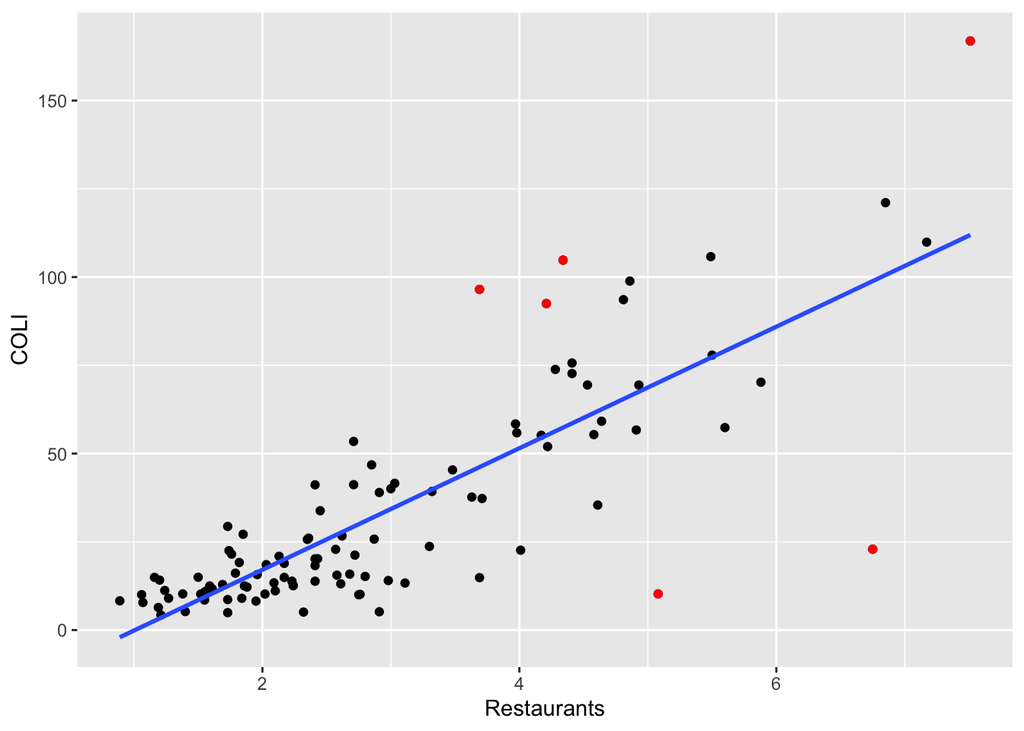

```r
std_residuals <- rstandard(mod1)
outlier_indices <- which(abs(std_residuals) > 2)  # Adjust the threshold if needed
outliers <- trainingset[outlier_indices, ]

ggplot(trainingset, aes(x = Restaurants, y = COLI)) +
  geom_point() +
  geom_smooth(method = "lm", se = FALSE) +
  geom_point(data = outliers, color = "red")
```

Let’s compute the correlation:

```r
mod1_correlation <- cor(coli_and_restaturnats$Restaurants, coli_and_restaturnats$COLI)
print(mod1_correlation)
```

```
## [1] 0.8058769
```

The plot shows a positive correlation between average restaurant cost and COLI. This means that cities with a higher COLI tend to have higher average restaurant costs. However, the correlation is not perfect, and there are some cities that deviate from the trend. Points scattered above and below the trend line represent cities that are outliers, meaning their restaurant costs are higher or lower than expected based on their COLI. The correlation coefficient of 0.8, which indicates that while there’s a tendency for these factors to rise together, the relationship is very reliable. A high coefficient indicates a strong linear relationship between the variables. This means that changes in one variable are associated with changes in the other variable in a predictable manner.

Even though cost of restaurants might be a good indicator/predictor of a city’s overall COLI to some extent, this doesn’t prove that expensive restaurants directly cause a higher COLI. There may be other economic factors that drive up both restaurant costs and other living expenses, contributing to the high correlation. That’s why, later on, we’ll perform a multiple linear regression.

Let’s analyse the model:

```r
summary(mod1)
```

```
##
## Call:
## lm(formula = COLI ~ Restaurants, data = trainingset)
##
## Residuals:
##     Min      1Q  Median      3Q     Max
## -75.946  -7.483   0.653   7.109  54.962
##
## Coefficients:
##             Estimate Std. Error t value Pr(>|t|)
## (Intercept)  -17.360      3.895  -4.457  2.1e-05 ***
## Restaurants   17.216      1.195  14.413  < 2e-16 ***
## ---
## Signif. codes:  0 '***' 0.001 '**' 0.01 '*' 0.05 '.' 0.1 ' ' 1
##
## Residual standard error: 17.95 on 104 degrees of freedom
## Multiple R-squared:  0.6664, Adjusted R-squared:  0.6632
## F-statistic: 207.7 on 1 and 104 DF,  p-value: < 2.2e-16
```

The “Std. Error” (more precise estimates) can be deduced from smaller standard errors that are a gauge of the ambiguity that comes along with coefficient estimates.

The coefficient estimate’s standard error distance from zero is measured by the “t-value”. Its purpose is to examine the likelihood of the coefficient being zero by testing the null hypothesis. A higher t-value’s absolute value indicates a higher possibility of statistical significance pertaining to the coefficient.

In summary, this low p-value suggests a statistically significant relationship between our predictor (Restaurants) and the outcome variable (COLI). The extremely low p-value (essentially 0) provides very strong evidence against the null hypothesis, which states there’s no relationship between COLI and restaurant cost.

### Predict values using predict function

```r
# Create a data frame with new input values
new_data <- data.frame(Restaurants = c(7.3, 7.5, 6.9, 7.8))
print(new_data)
```

```
##   Restaurants
## 1         7.3
## 2         7.5
## 3         6.9
## 4         7.8
```

```r
# Predict using the linear regression model
predicted_restaurant_costs <- predict(mod1, newdata = new_data)

# Display the predicted salaries
print(predicted_restaurant_costs)
```

```
##        1        2        3        4
## 108.3165 111.7597 101.4301 116.9245
```

### Visualising the Training set results

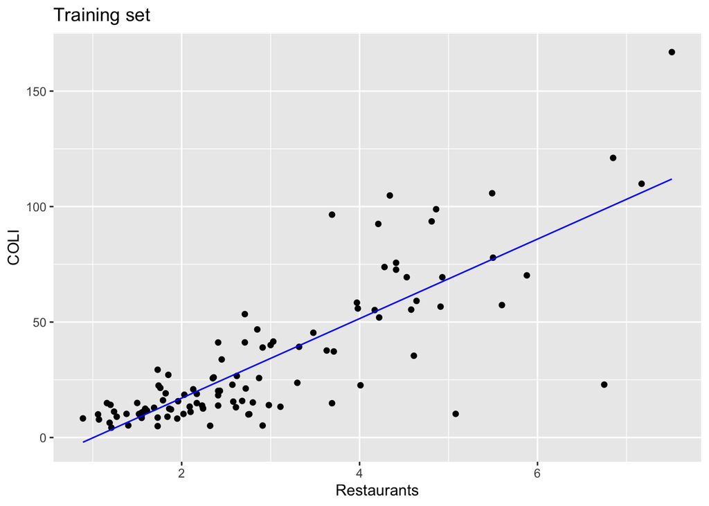

```r
ggplot() +
geom_point(
aes(x = trainingset$Restaurants, y = trainingset$COLI), colour = 'black') +
geom_line(aes(x = trainingset$Restaurants, y = predict(mod1, newdata = trainingset)), colour = 'blue') +
ggtitle('Training set') +
xlab('Restaurants') +
ylab('COLI')
```

### Visualising the Test set results

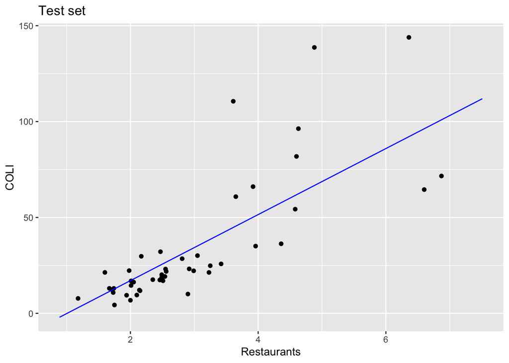

```r
ggplot() +
geom_point(aes(x = testset$Restaurants, y = testset$COLI), colour = 'black') +
geom_line(aes(x = trainingset$Restaurants, y = predict(mod1, newdata = trainingset)), colour = 'blue') +
ggtitle('Test set') +
xlab('Restaurants') +
ylab('COLI')
```

## 7.2) COLI VS Average Market Costs

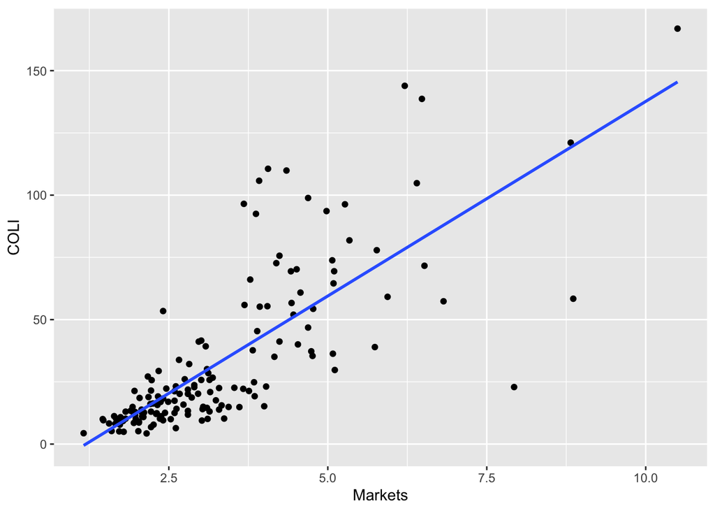

```r
coli_and_markets <- basket3[,c("Markets", "COLI")]

attach(coli_and_markets)

ggplot(coli_and_markets, aes(x = Markets, y = COLI)) +
  geom_point() +
  geom_smooth(method = "lm", se = FALSE) +  # Adds a trend line
  labs(x = "Markets",y = "COLI")
```

```r
# Regression
mod2 <- lm(COLI ~ Markets)

summary(mod2)
```

```
##
## Call:
## lm(formula = COLI ~ Markets)
##
## Residuals:
##     Min      1Q  Median      3Q     Max
## -82.389  -9.497  -1.604   5.368  65.809
##
## Coefficients:
##             Estimate Std. Error t value Pr(>|t|)
## (Intercept)  -18.697      3.895  -4.801 3.79e-06 ***
## Markets       15.635      1.064  14.701  < 2e-16 ***
## ---
## Signif. codes:  0 '***' 0.001 '**' 0.01 '*' 0.05 '.' 0.1 ' ' 1
##
## Residual standard error: 20.29 on 150 degrees of freedom
## Multiple R-squared:  0.5903, Adjusted R-squared:  0.5876
## F-statistic: 216.1 on 1 and 150 DF,  p-value: < 2.2e-16
```

```r
detach(coli_and_markets)
```

Correlation

```r
mod2_correlation <- cor(coli_and_markets$Markets, coli_and_markets$COLI)
print(mod2_correlation)
```

```
## [1] 0.7683135
```

## 7.3) COLI VS Average MonthlyRent Costs

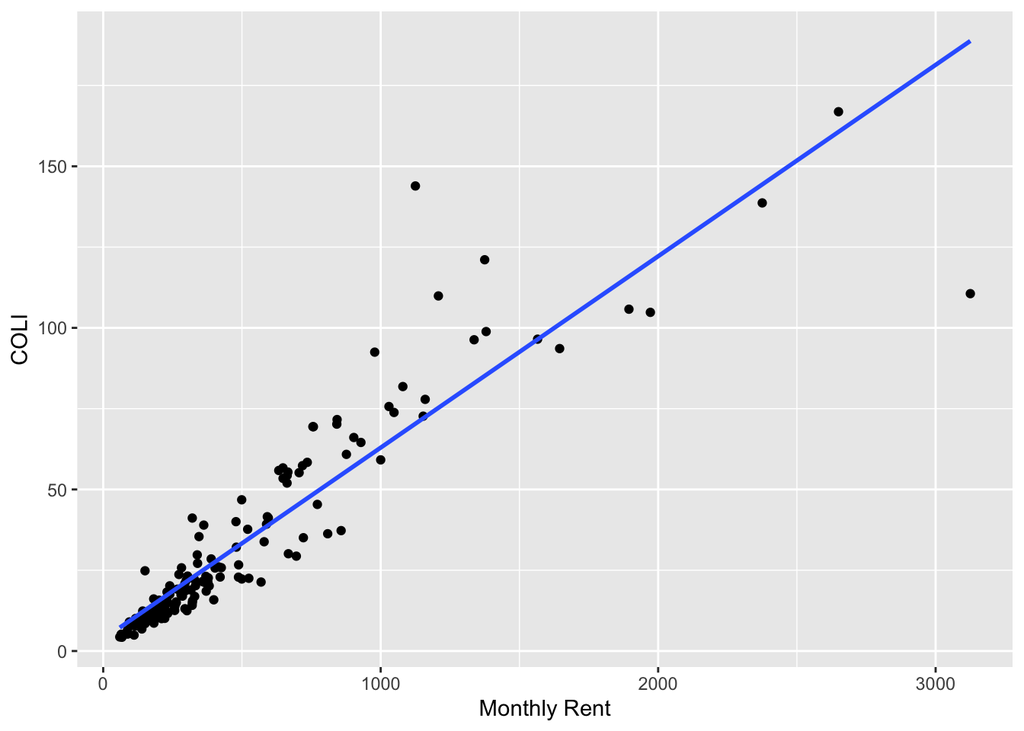

```r
coli_and_monthlyRent <- basket3[,c("MonthlyRent", "COLI")]

attach(coli_and_monthlyRent)

ggplot(coli_and_monthlyRent, aes(x = MonthlyRent, y = COLI)) +
  geom_point() +
  geom_smooth(method = "lm", se = FALSE) +  # Adds a trend line
  labs(x = "Monthly Rent",y = "COLI")
```

```r
# Regression
mod3 <- lm(COLI ~ MonthlyRent)

summary(mod3)
```

```
##
## Call:
## lm(formula = COLI ~ MonthlyRent)
##
## Residuals:
##     Min      1Q  Median      3Q     Max
## -78.201  -4.747  -2.502   2.904  73.570
##
## Coefficients:
##             Estimate Std. Error t value Pr(>|t|)
## (Intercept) 3.709829   1.452466   2.554   0.0116 *
## MonthlyRent 0.059224   0.002083  28.436   <2e-16 ***
## ---
## Signif. codes:  0 '***' 0.001 '**' 0.01 '*' 0.05 '.' 0.1 ' ' 1
##
## Residual standard error: 12.54 on 150 degrees of freedom
## Multiple R-squared:  0.8435, Adjusted R-squared:  0.8425
## F-statistic: 808.6 on 1 and 150 DF,  p-value: < 2.2e-16
```

```r
attach(coli_and_monthlyRent)
```

Correlation

```r
mod3_correlation <- cor(coli_and_monthlyRent$MonthlyRent, coli_and_monthlyRent$COLI)
print(mod3_correlation)
```

```
## [1] 0.918434
```

```r
coli_and_salary <- basket3[,c("Salaries", "COLI")]

attach(coli_and_salary)
```

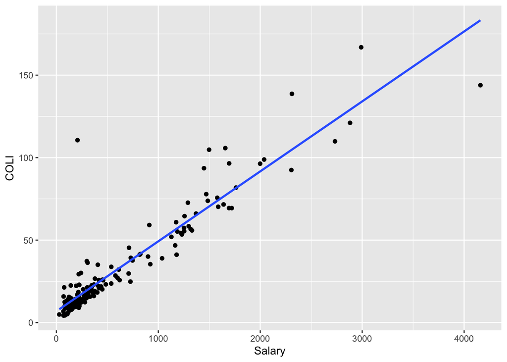

```r
ggplot(coli_and_salary, aes(x = Salaries, y = COLI)) +
  geom_point() +
  geom_smooth(method = "lm", se = FALSE) +  # Adds a trend line
  labs(x = "Salary",y = "COLI")
```

```r
# Regression
mod4 <- lm(COLI ~ Salaries)

summary(mod4)
```

```
##
## Call:
## lm(formula = COLI ~ Salaries)
##
## Residuals:
##     Min      1Q  Median      3Q     Max
## -39.352  -4.799  -2.481   1.477  94.927
##
## Coefficients:
##             Estimate Std. Error t value Pr(>|t|)
## (Intercept) 6.855838   1.282840   5.344 3.31e-07 ***
## Salaries    0.042406   0.001382  30.681  < 2e-16 ***
## ---
## Signif. codes:  0 '***' 0.001 '**' 0.01 '*' 0.05 '.' 0.1 ' ' 1
##
## Residual standard error: 11.75 on 150 degrees of freedom
## Multiple R-squared:  0.8626, Adjusted R-squared:  0.8616
## F-statistic: 941.3 on 1 and 150 DF,  p-value: < 2.2e-16
```

```r
detach(coli_and_salary)
```

## 7.5) COLI VS Average Meal Costs

```r
coli_and_meal <- basket3[,c("Meal", "COLI")]

attach(coli_and_meal)
```

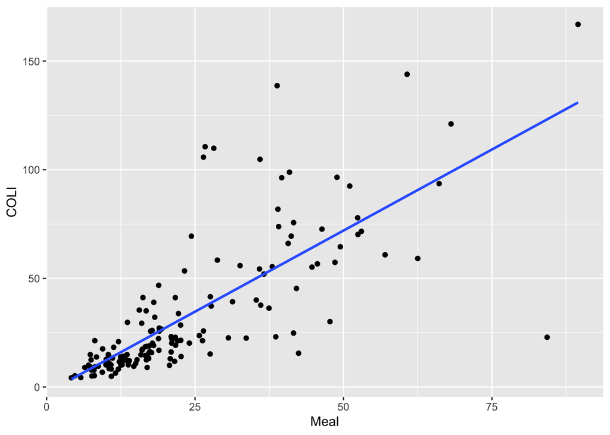

```r
ggplot(coli_and_meal, aes(x = Meal, y = COLI)) +
  geom_point() +
  geom_smooth(method = "lm", se = FALSE) +  # Adds a trend line
  labs(x = "Meal",y = "COLI")
```

```r
# Regression
mod5 <- lm(COLI ~ Meal)

summary(mod5)
```

```
##
## Call:
## lm(formula = COLI ~ Meal)
##
## Residuals:
##      Min       1Q   Median       3Q      Max
## -100.265   -8.386   -3.265    3.554   83.348
##
## Coefficients:
##             Estimate Std. Error t value Pr(>|t|)
## (Intercept)  -2.6049     3.0332  -0.859    0.392
## Meal          1.4921     0.1052  14.179   <2e-16 ***
## ---
## Signif. codes:  0 '***' 0.001 '**' 0.01 '*' 0.05 '.' 0.1 ' ' 1
##
## Residual standard error: 20.72 on 150 degrees of freedom
## Multiple R-squared:  0.5727, Adjusted R-squared:  0.5698
## F-statistic:   201 on 1 and 150 DF,  p-value: < 2.2e-16
```

```r
detach(coli_and_meal)
```

Correlation

```r
mod5_correlation <- cor(coli_and_meal$Meal, coli_and_meal$COLI)
print(mod5_correlation)
```

```
## [1] 0.7567649
```

Now we try a multiple linear regression to see if changes in COLI are affected by many factors. By including additional predictors, you often significantly increase the R-squared value, meaning the model explains a greater amount of the variation in your target variable. Multiple linear regression helps you see which predictors carry the most explanatory weight, even when other variables are considered.

To identify good predictors to include in our model, we analyse the correlations between the predictors and the target variable, which is the COLI.

```r
cols <- names(basket3)
cols <- cols[-1] #remove country column
cols <- cols[1:6] #remove COLI column

for (col in cols) {
  idx <- which(colnames(basket) == col)
  tmp <- basket[,idx]
  cor <- cor(tmp, basket3$COLI)
  cat(col,cor,'\n')
}
```

```
## Meal 0.7567649
## Restaurants 0.8058769
## Markets 0.7683135
## Transports 0.6230504
## MonthlyRent 0.918434
## Salaries 0.9287362
```

The categories with the highest correlation are: - Restaurants - Markets - MonthlyRent - Salaries

Let’s add them into our model:

```r
mod6 <- lm(formula = COLI ~ Restaurants + Markets + MonthlyRent + Salaries, data = basket3)
summary(mod6)
```

```
##
## Call:
## lm(formula = COLI ~ Restaurants + Markets + MonthlyRent + Salaries,
##     data = basket3)
##
## Residuals:
##      Min       1Q   Median       3Q      Max
## -1.02915 -0.14226  0.00136  0.11492  1.09721
##
## Coefficients:
##               Estimate Std. Error t value Pr(>|t|)
## (Intercept) -1.494e-01  7.343e-02  -2.034   0.0437 *
## Restaurants  1.923e-01  3.862e-02   4.979 1.76e-06 ***
## Markets      1.634e-01  3.205e-02   5.098 1.04e-06 ***
## MonthlyRent  3.347e-02  8.039e-05 416.277  < 2e-16 ***
## Salaries     2.508e-02  6.763e-05 370.837  < 2e-16 ***
## ---
## Signif. codes:  0 '***' 0.001 '**' 0.01 '*' 0.05 '.' 0.1 ' ' 1
##
## Residual standard error: 0.3215 on 147 degrees of freedom
## Multiple R-squared:  0.9999, Adjusted R-squared:  0.9999
## F-statistic: 3.645e+05 on 4 and 147 DF,  p-value: < 2.2e-16
```

```r
summary(mod1)$r.squared
```

```
## [1] 0.6663714
```

```r
summary(mod6)$r.squared
```

```
## [1] 0.9998992
```

The model explains approximately 99% of the variation in COLI. This suggests the chosen predictors have a strong relationship with the COLI. The adjusted R-squared is very close to the normal R-squared, this is another sign suggesting our chosen predictors fit well the model. There is no big difference between R-squared and adjusted R-squared, it indicates our model is not overly complex and likely generalizes well to new data, it’s no affaccted by overfitting.

Let’s see graphically how it looks

### Residuals vs. Fitted Values

This plot is useful to check the linearity and for detecting heteroscedasticity. Since most of the residuals are scattered randomly around zero we can say that there is linearity between residuals and fitted values.

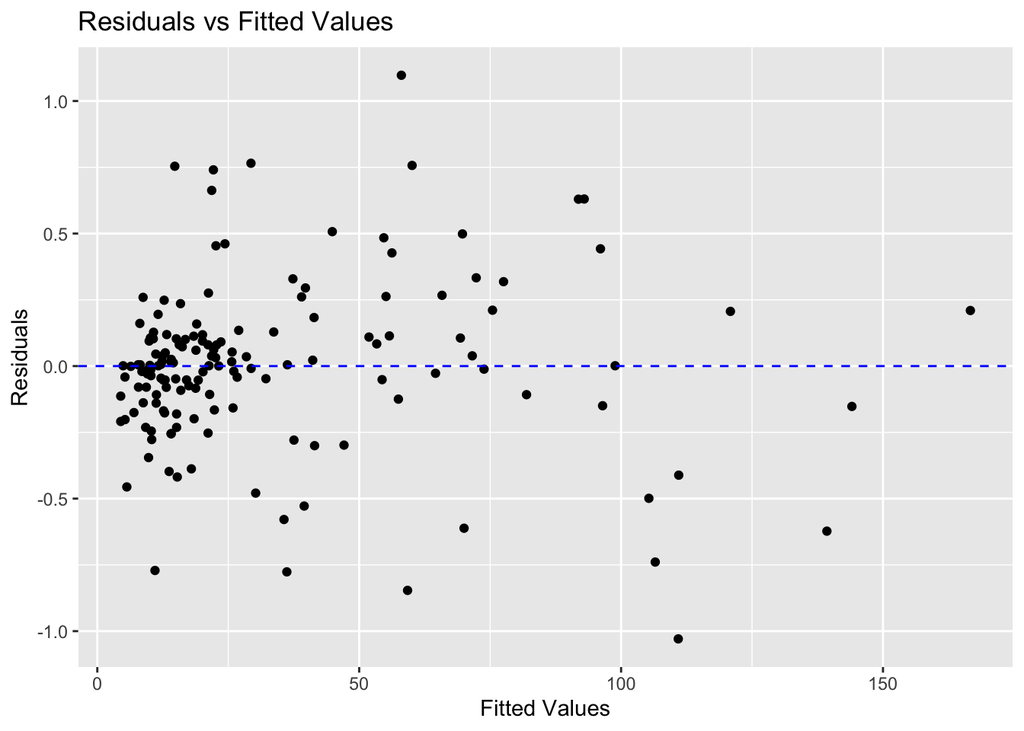

```r
ggplot(mod6, aes(x = fitted.values(mod6), y = residuals(mod6))) +
geom_point() +
geom_hline(yintercept = 0, linetype = "dashed",colour = 'blue') +
labs(x = "Fitted Values", y = "Residuals", title = "Residuals vs Fitted Values")
```

### Normal Q-Q Plot of Residuals

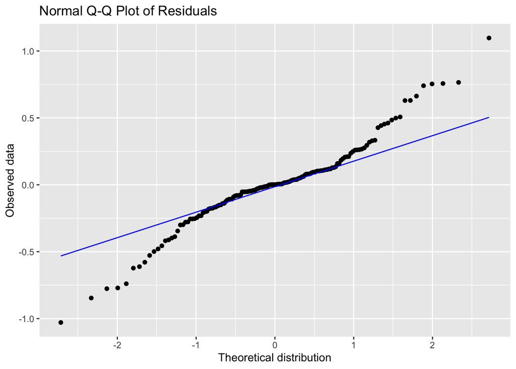

```r
ggplot(mod6, aes(sample = residuals(mod6))) +
stat_qq() +
stat_qq_line(colour = 'blue') +
labs(x = "Theoretical distribution", y = "Observed data", title = "Normal Q-Q Plot of Residuals")
```

However, there are a few deviations from the ideal straight line: - The tails of the distribution seem to be slightly heavier than normal. This means that there are a few more data points than expected in the extreme tails, which could indicate the presence of outliers or non-linear relationships in your data. - There seems to be a slight curvature in the center of the plot, with some points deviating above and below the line. This could indicate that there are some systematic patterns in the residuals that are not being captured by your model

### Residuals vs Individual Predictors

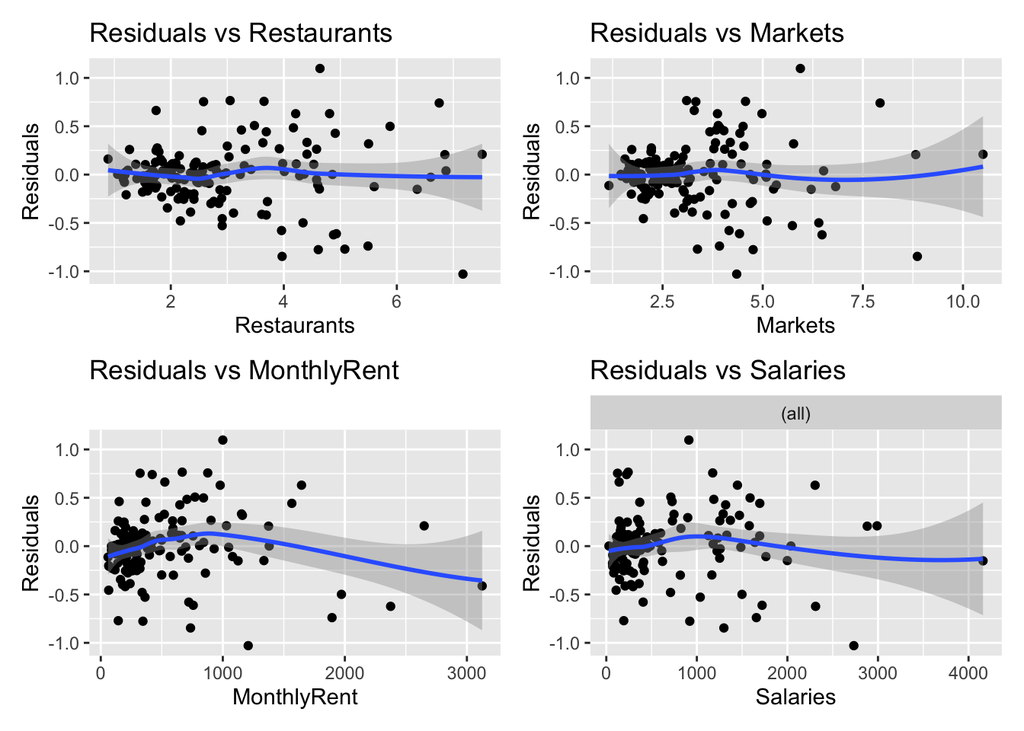

```r
library(patchwork)

plot1 <- ggplot(mod6, aes(x = basket3$Restaurants, y = residuals(mod6))) +
  geom_point() +
  geom_smooth() +
  labs(x = "Restaurants", y = "Residuals", title = paste("Residuals vs Restaurants"))

plot2 <- ggplot(mod6, aes(x = basket3$Markets, y = residuals(mod6))) +
  geom_point() +
  geom_smooth() +
  labs(x = "Markets", y = "Residuals", title = paste("Residuals vs Markets"))

plot3 <- ggplot(mod6, aes(x = basket3$MonthlyRent, y = residuals(mod6))) +
  geom_point() +
  geom_smooth() +
  labs(x = "MonthlyRent", y = "Residuals", title = paste("Residuals vs MonthlyRent"))

plot4 <- ggplot(mod6, aes(x = basket3$Salaries, y = residuals(mod6))) +
  geom_point() +
  geom_smooth() +
  labs(x = "Salaries", y = "Residuals", title = paste("Residuals vs Salaries"))

combined_plot <- plot1 + plot2 + plot3 + plot4 + facet_wrap(~ ., nrow = 2)

print(combined_plot)
```